# Airline Cancellations, Delays, and Geography

April 24, 2016

## DATASET

The dataset consists of on-time performance statistics from the Bureau of Transportation Statistics ranging across the month of January in 2016. (http://1.usa.gov/1YP4p5m)

Once I uploaded the dataset, I converted the airline i.d.s to factors, to make using ggplot easier.

```r
airdata2 <- read.csv("~/RClass1/airdata2.csv")
airdata2$AIRLINE_ID <- as.factor(airdata2$AIRLINE_ID)
flightdate <- airdata2
```

## Are departure delays related to arrival delays?

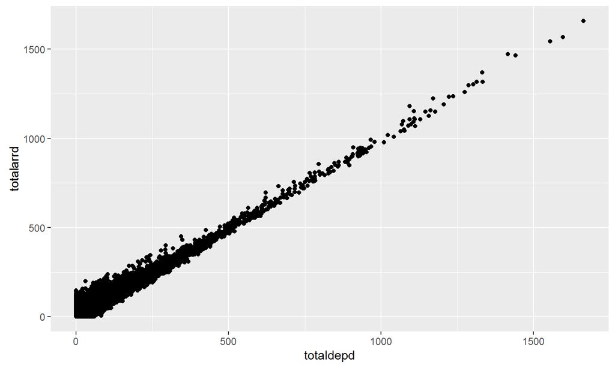

## Cancellations and Flight Date

Did any particular days experience a higher ratio of cancellations per number of flights than others?

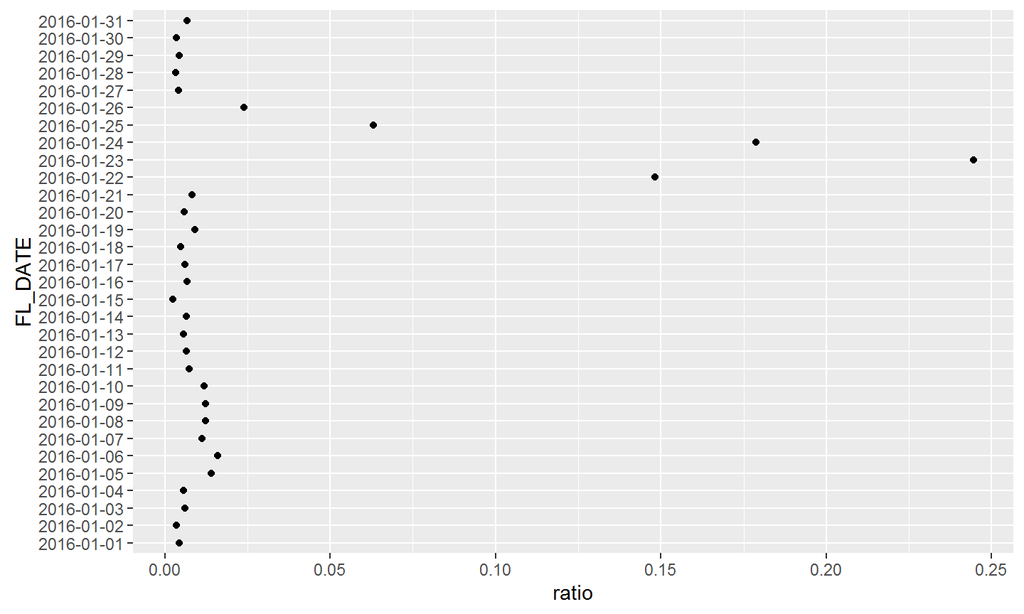

## Blizzard pattern for large airlines

I looked at Southwest Airlines (19393), American Airlines (19805), and Delta Airlines (19790).

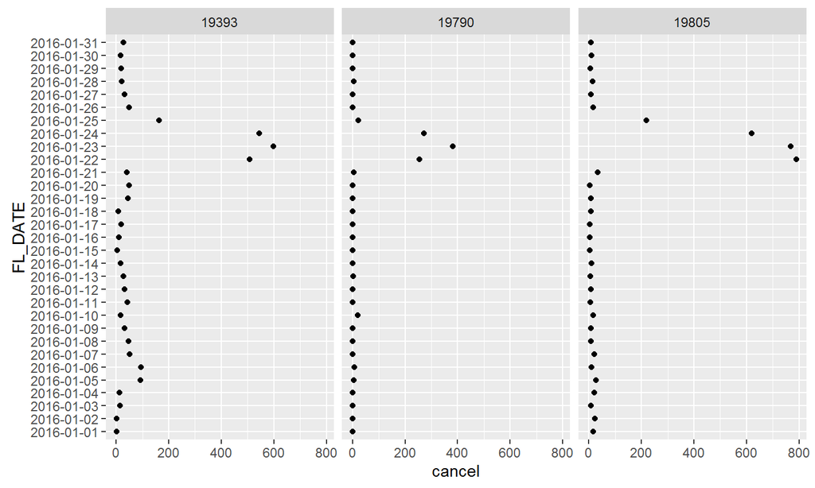

## Ratio of cancelled to total flights

The pattern is more severe for the larger airlines than the smaller ones, Alaska Airlines (19930) and Hawaiian Airlines (19690), with Alaska Airlines having a relative spike on the blizzard days.

## Ratio of cancelled to total flights

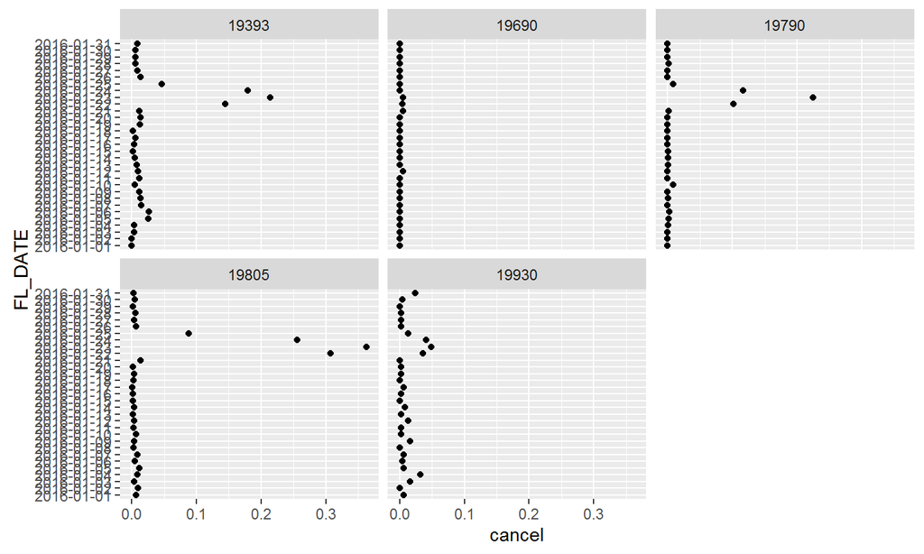

## Geography and flight patterns

During the blizzard, many larger airline flights originated from blizzard states (Georgia, Florida, North Carolina, Texas).

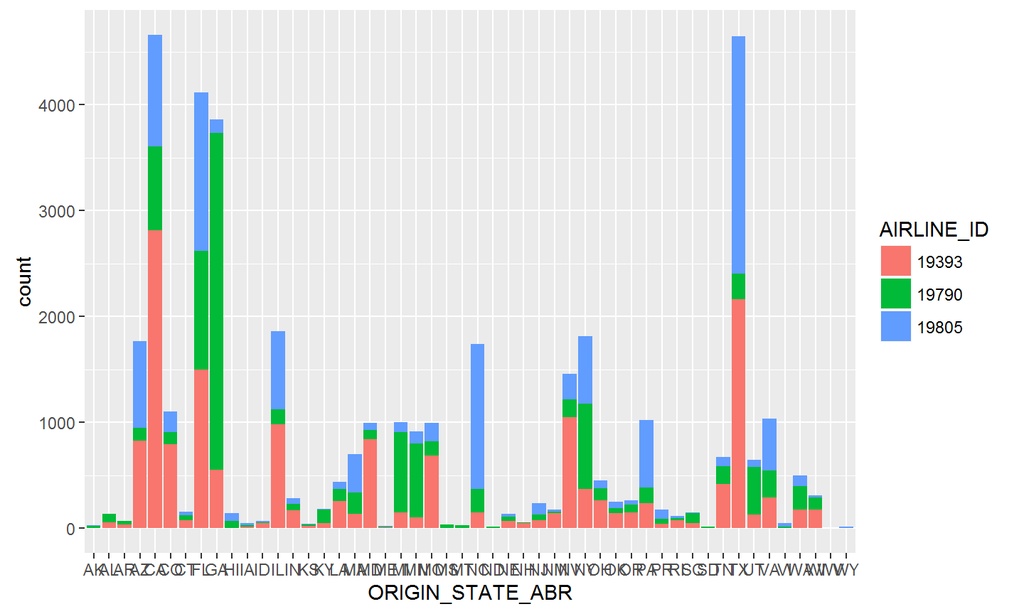

## Smaller airlines

Hawaiian Airlines' and Alaska Airlines' flights fit a different pattern.

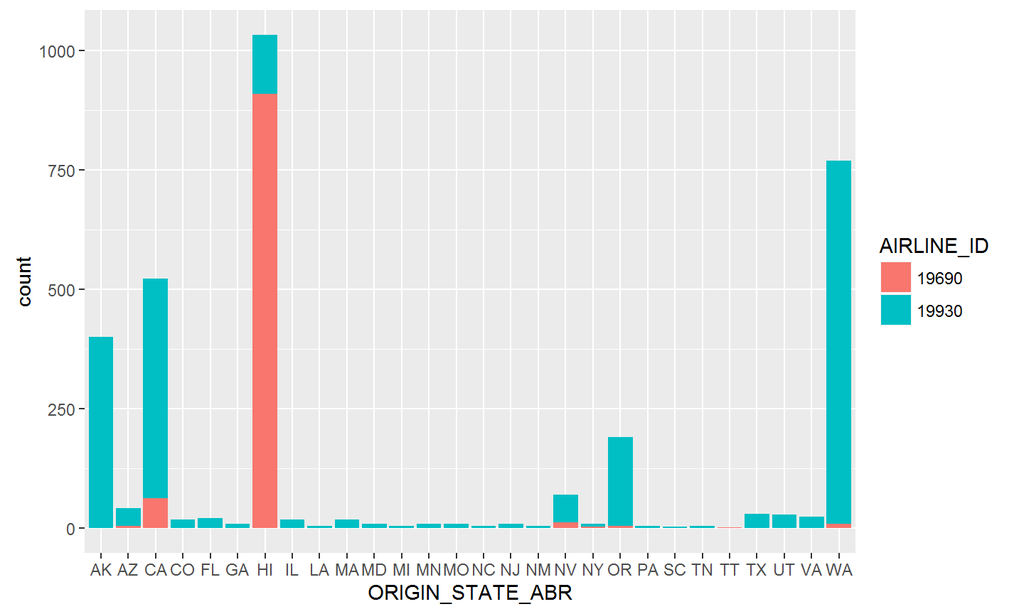

## For all airlines

Where did most of the blizzard cancellations occur?

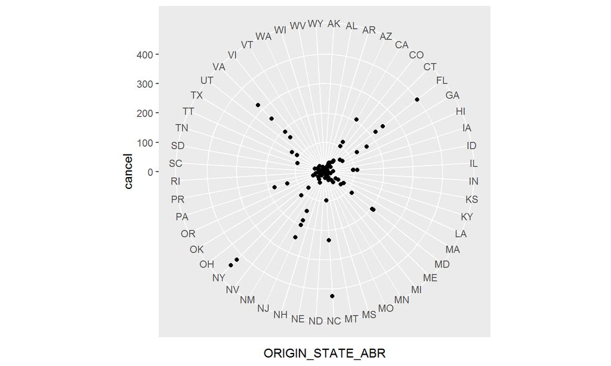

Florida, North Carolina, Maryland, New York, and Virginia.

## Departure delays and geography.1

Do departure delays have the same pattern as cancelled flights?

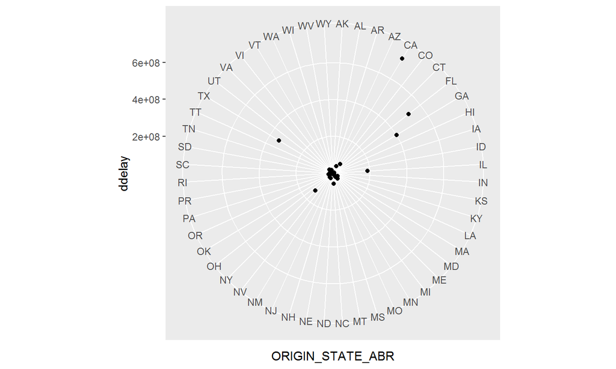

## Departure delays and geography.2

Why does California, a state unaffected by the blizzard, have worse departure delay times than Georgia, Florida, and Texas?